# Developing Data Products - Shiny App Assignment

Anju Mandal

April 6, 2019

## Introduction

This assigment uses the Shiny packagae in R to create an app that will predict the Ozone levels based on the Temperature inputs.

The application used the ‘airquality’ dataset provided within R. This data set consists of the daily air quality measurements in New York, May to September 1973

Details of the Data

- Ozone: Mean ozone in parts per billion from 1300 to 1500 hours at Roosevelt Island
- Solar.R: Solar radiation in Langleys in the frequency band 4000-7700 Angstroms from 0800 to 1200 hours at Central Park -Wind: Average wind speed in miles per hour at 0700 and 1000 hours at LaGuardia Airport
- Temp: Maximum daily temperature in degrees Fahrenheit at La Guardia Airport.

## Application Details -User Interface

The UI consists of the following parts

- A slider input that will allow the user to select the appropriate Temperature for which they wish to predict the associated Ozone Level.
- Predict button which the user needs to press to predict the new value based on Temperature selection
- A scatter plot of all the readings available within the data, a line depitcing the linear model that was fitted and a red dot to display the predicted value
- Text that will display the predicted value

## Application Details - Calculations

The Server code will do the following

- Clean the Data to remove any ‘NA’ fields
- Fit a linear regression model on the data
- Read the new Temperature value selected on the slider
- Predict the new values based on the model fitted earlier
- Display the scatter plot for the entire data, mark the linar model as a line and add a point to depict the newly predicted value
- Display the predicted value as text

## How to use the Application

The user will need to select the desired temperature on the slider and then press the ‘Predict’ button , this will calculate/predict the new value and display it a ‘Red’ dot on the plot and as text below the plot .

Location of the Shiny App

https://anjup2208.shinyapps.io/AirQuality/

Location of the Code on Github

https://github.com/anjup2208/DDP

## Screen cast of the Application

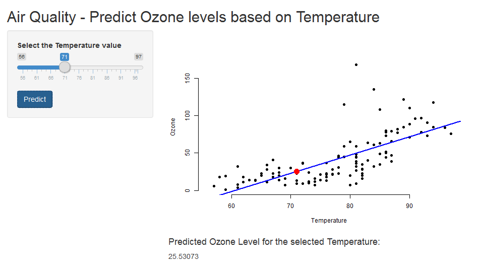